# Chapter 6 - Multidimensional scaling: exercises

Author

Prof. Richard Wilkinson

## Question 1

1. Define
   $$b_{ij}=(\mathbf x_i-\bar{\mathbf x})^\top (\mathbf x_j-\bar{\mathbf x}), \quad i,j=1, \ldots , n,$$
   and write $\mathbf B=(b_{ij})_{i,j=1}^n$. Prove that
   $$\mathbf B=(\mathbf H\mathbf X)(\mathbf H\mathbf X)^\top,$$
   where $\mathbf H$ is the $n \times n$ centering matrix and $\mathbf X= (\mathbf x_1, \ldots , \mathbf x_n)^\top$ is the data matrix.

**Solution**

We have seen previously that
$$\mathbf H\mathbf X= \begin{pmatrix} (\mathbf x_1-\bar{\mathbf x})^\top \\...\\...\\(\mathbf x_n -\bar{\mathbf x})^\top \end{pmatrix},$$
so
$$\begin{align*}
\mathbf H\mathbf X(\mathbf H\mathbf X)^\top &=\begin{pmatrix} (\mathbf x_1-\bar{\mathbf x})^\top \\...\\...\\(\mathbf x_n -\bar{\mathbf x})^\top \end{pmatrix}(\mathbf x_1 -\bar{\mathbf x}, \ldots , \mathbf x_n -\bar{\mathbf x})\\
&=\begin{pmatrix} (\mathbf x_1 -\bar{\mathbf x})^\top (\mathbf x_1 -\bar{\mathbf x}) &... & ...& ...&(\mathbf x_1-\bar{\mathbf x})^\top (\mathbf x_n -\bar{\mathbf x})\\
...&... &... &...&...\\
...&... &...&...&...\\
...&... &...&...&...\\
(\mathbf x_n-\bar{\mathbf x})^\top (\mathbf x_1-\bar{\mathbf x})&...&...&...&(\mathbf x_n-\bar{\mathbf x}^\top (\mathbf x_n-\bar{\mathbf x})
\end{pmatrix}\\
&=(b_{ij})_{i,j=1}^n =\mathbf B,
\end{align*}$$
as required.

2. Show that $\mathbf B$ is positive semi-definite, i.e., explain why, for all $n \times 1$ vectors $\mathbf a$,
   $$\mathbf a^\top \mathbf B\mathbf a=\mathbf a^\top (\mathbf H\mathbf X) (\mathbf H\mathbf X)^\top \mathbf a\geq 0.$$

**Solution**

From part i.,
$$\begin{align*}
\mathbf a^\top \mathbf B\mathbf a&=\mathbf a^\top \mathbf H\mathbf X(\mathbf H\mathbf X)^\top \mathbf a\\
&=\mathbf a^\top \mathbf H\mathbf X\mathbf X^\top \mathbf H^\top \mathbf a\\
&=\mathbf b^\top \mathbf b=\sum_{i=1}^n b_i^2 \geq 0,
\end{align*}$$
where $\mathbf b=(b_1, \ldots , b_n)^\top$ is the vector $\mathbf b=\mathbf X^\top \mathbf H^\top \mathbf a$. This holds for any $\mathbf a$, and consequently $\mathbf B$ is positive semi-definite.

## Question 2

1. Prove that if $\mathbf A$ is a symmetric $n \times n$ matrix, then
   $$\mathbf B= \mathbf H\mathbf A\mathbf H$$
   has elements given by
   $$b_{ij}=a_{ij}-\bar{a}_{i+}-\bar{a}_{+j}+\bar{a}_{++}, \qquad i,j=1, \ldots , n,$$
   where
   $$\bar{a}_{i+}= \frac{1}{n} \sum_{j=1}^n a_{ij}, \quad \bar{a}_{+j}=\frac{1}{n} \sum_{i=1}^n a_{ij}, \quad\mbox{and} \quad\bar{a}_{++} = \frac{1}{n^2} \sum_{i,j=1}^n a_{ij}.$$

**Solution**

Suppose $\mathbf A$ is a symmetric $n \times n$ matrix. Then
$$\begin{align}
\mathbf B&=\mathbf H\mathbf A\mathbf H\nonumber\\
&=(\mathbf I_n -n^{-1}{\bf 1}_n {\bf 1}_n^\top )\mathbf A(\mathbf I_n -n^{-1}{\bf 1}_n {\bf 1}_n^\top )\nonumber\\
&=\mathbf A-{\bf 1}_n (n^{-1}{\bf 1}_n^\top \mathbf A)-(n^{-1}\mathbf A{\bf 1}_n){\bf 1}_n^\top -{\bf 1}_n(n^{-2}{\bf 1}_n^\top \mathbf A{\bf 1}_n) {\bf 1}_n^\top \nonumber\\
&=\mathbf A-{\bf 1}_n \bar{\mathbf a}_+^\top -\bar{\mathbf a}_+ {\bf 1}_n^\top +\bar{a}_{++} {\bf 1}_n {\bf 1}_n^\top,
\label{matrixformB}
\end{align}$$
where
$$\bar{\mathbf a}_+ \equiv (\bar{a}_{1+}, \ldots , \bar{a}_{n+})^\top =n^{-1}\mathbf A{\bf 1}_n=(n^{-1}{\bf 1}^\top \mathbf A)^\top, \qquad \bar{a}_{i+}=n^{-1}\sum_{j=1} a_{ij}$$
and
$$\bar{a}_{++}=n^{-2}\sum_{i,j=1}^n a_{ij}.$$
Consequently,
$$\begin{equation}
b_{ij}=a_{ij}-\bar{a}_{i+}-\bar{a}_{+j}+\bar{a}_{++} \qquad i,j=1, \ldots , n,
\label{bij}
\end{equation}$$
where, by symmetry of $\mathbf A$, $\bar{a}_{+j}=\bar{a}_{j+}$.

2. Assume that $\mathbf B$ is positive semi-definite with $k$ strictly positive eigenvalues and let
   $$\mathbf B= \sum_{j=1}^k \lambda_j \mathbf u_j\mathbf u_j^\top =\mathbf U\boldsymbol \Lambda\mathbf U^\top,$$
   where $\boldsymbol \Lambda=\text{diag}\{\lambda_1, \ldots , \lambda_k\}$ and $\mathbf U$ is $n \times k$ and satisfies $\mathbf U^\top \mathbf U=\mathbf I_k$. Now define a ‘new’ $n \times k$ data matrix
   $$\mathbf X=[\mathbf x_1, \ldots , \mathbf x_n]^\top=\mathbf U\boldsymbol \Lambda^{1/2}.$$
   Show that $b_{ij}=\mathbf x_i^\top \mathbf x_j$ for all $i,j=1, \ldots , n$.
   **Hint**: check that for $\mathbf X$ defined as above, $\mathbf X\mathbf X^\top =\mathbf B$.

**Solution**

We have
$$\begin{align*}
\mathbf X\mathbf X^\top &=\mathbf U\boldsymbol \Lambda^{1/2} (\mathbf U\boldsymbol \Lambda^{1/2})^\top\\
&=\mathbf U\boldsymbol \Lambda^{1/2} \boldsymbol \Lambda^{1/2}\mathbf U^\top =\mathbf U\boldsymbol \Lambda\mathbf U^\top = \mathbf B.
\end{align*}$$
So
$$\begin{align*}
\mathbf B&=\mathbf X\mathbf X^\top\\
&=\begin{pmatrix} \mathbf x_1^\top \\...\\...\\...\\\mathbf x_n^\top \end{pmatrix}(\mathbf x_1, \ldots , \mathbf x_n)\\
&=\begin{pmatrix} \mathbf x_1^\top \mathbf x_n &...&...&...&\mathbf x_1^\top \mathbf x_n\\
...&...&...&...&...\\
...&...&...&...&...\\
...&...&...&...&...\\
\mathbf x_n^\top \mathbf x_1 &...&...&...&\mathbf x_n^\top \mathbf x_n,
\end{pmatrix}
\end{align*}$$
and consequently $b_{ij}=\mathbf x_i^\top \mathbf x_j$, as required.

3. We now need to show that $\mathbf D=(d_{ij})$ represents the set of inter-point distances for this new data matrix. Recall that $a_{ij}=-d_{ij}^2/2$. Deduce that
   $$(\mathbf x_i -\mathbf x_j)^\top (\mathbf x_i-\mathbf x_j)= b_{ii} + b_{jj}-2b_{ij};$$
   and so, using the first part of this question, show that
   $$(\mathbf x_i -\mathbf x_j)^\top (\mathbf x_i-\mathbf x_j)=-2a_{ij}=d_{ij}^2.$$
   Hence the new inter-point distances are the same as the original ones.

**Solution**

Using part (b) of this question,
$$\begin{align}
b_{ii}+b_{jj}-2b_{ij}&=\mathbf x_i^\top \mathbf x_i +\mathbf x_j^\top \mathbf x_j-\mathbf x_i^\top \mathbf x_j - \mathbf x_j^\top \mathbf x_i \nonumber \\
&=(\mathbf x_i-\mathbf x_j)^\top (\mathbf x_i-\mathbf x_j).
\label{biijj}
\end{align}$$

Substituting for $b_{ij}$ on the LHS, we obtain
$$\begin{align}
(\mathbf x_i-\mathbf x_j)^\top (\mathbf x_i-\mathbf x_j)&=b_{ii}+b_{jj}-2b_{ij}\\
&= a_{ii}-2\bar{a}_{i+}+\bar{a}_{++} +a_{jj}-2\bar{a}_{j+}+\bar{a}_{++}\\
& \qquad - 2(a_{ij}-\bar{a}_{i+}-\bar{a}_{+j}+\bar{a}_{++})\\
&=a_{ii}+a_{jj}-2a_{ij}.
\label{aiijj}
\end{align}$$
Moreover, if we write $a_{ij}=-d_{ij}^2/2$, with $a_{ii}=a_{jj}=0$, then
$$(\mathbf x_i-\mathbf x_j)^\top (\mathbf x_i -\mathbf x_j)=-2a_{ij}=d_{ij}^2.$$
Consequently, the inter-point distances of the new points $\mathbf x_1, \ldots ,\mathbf x_n$ are given by the original distance matrix $\mathbf D$, which is what we wanted to prove.

Finally, we note that $\bar{\mathbf x}=n^{-1}\sum_{i=1}^n \mathbf x_i ={\bf 0}_k$, i.e. the sample mean vector of the new points is the zero vector, because
$$\begin{equation}
\bar{\mathbf x}=n^{-1}\mathbf X^\top {\bf 1}_n=\boldsymbol \Lambda^{1/2}\mathbf U^\top {\bf 1}_n={\bf 0}_k.
\label{boldbarx}
\end{equation}$$
This is a consequence of the fact that $\mathbf U^\top {\bf 1}_n={\bf 0}_k$, which is the case because the columns of $\mathbf U$ are unit eigenvectors associated with strictly positive eigenvalues of $\mathbf B=\mathbf U\boldsymbol \Lambda\mathbf U^\top$, while ${\bf 1}_n$ is an eigenvector of $\mathbf B$ corresponding to a zero eigenvalue of $\mathbf B$, hence ${\bf 1}_n$ is orthogonal to the columns of $\mathbf U$.

## Question 3

Suppose $\mathbf X$ is a $n \times p$ column centred data matrix. PCA looks at the spectral decomposition of the covariance matrix $\frac{1}{n}\mathbf X^\top \mathbf X$, whereas MDS uses the spectral decomposition of the Gram matrix $\mathbf X\mathbf X^\top$. Using the SVD for $\mathbf X=\mathbf U\boldsymbol{\Sigma}\mathbf V^\top$, explain the relationship between these two methods.

**Solution**

Suppose $\mathbf X$ has SVD
$$\mathbf X= \mathbf U\boldsymbol{\Sigma}\mathbf V^\top$$

$$\mathbf S=\frac{1}{n}\mathbf X^\top \mathbf X= \mathbf V\boldsymbol{\Sigma}^2 \mathbf V^\top$$
so we can see the covariance matrix has the same eigenvalues as the Gram matrix. The PC scores are given by

$$\mathbf Y=\mathbf X\mathbf V=\mathbf U\boldsymbol{\Sigma}$$
which is exactly the same as the MDS coordinates.

## Question 4

This question is from the 2018-19 exam.

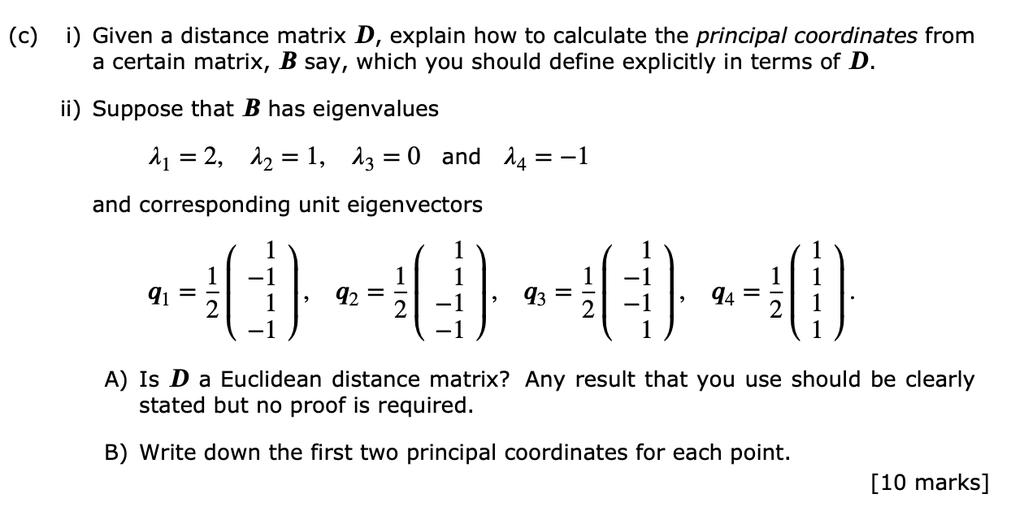

**Solution**

1. $\mathbf B= \mathbf H\mathbf A\mathbf H$ where $a_{ij}=-\frac{1}{2}d_{ij}^2$. Here $\mathbf H$ is the centering matrix:
   $$\mathbf H=\mathbf I-\frac{1}{n}\mathbf{1}\mathbf{1}^\top$$
   If $\mathbf B$ has spectral decomposition
   $$\mathbf B= \sum_i \lambda_i \mathbf q_i \mathbf q_i^\top$$
   then the first $k$ principal coordinates are given by
   $$\mathbf X= \begin{pmatrix}-&\mathbf x_1^\top&-\\& \vdots& \\-&\mathbf x_n^\top&-\end{pmatrix} = \begin{pmatrix}|&\ldots &|\\\mathbf v_1 &\ldots & \mathbf v_k\\|&\ldots &|\end{pmatrix}\operatorname{diag}\{\lambda_1^{0.5}, \ldots, \lambda_k^{0.5}\}$$
   assuming that $\lambda_k >0$.
2. No, $\mathbf D$ is not Euclidean because it is has a negative eigenvalue, so $\mathbf B$ is not positive definite.

The first two principal coordinates are

```r
Q <- matrix(0.5*c(1,-1,1,-1,
                  1,1,-1,-1), nc=2, byrow=F)
Lambda <- diag(c(sqrt(2), sqrt(1)))
Q%*% Lambda
```

```
           [,1] [,2]
[1,]  0.7071068  0.5
[2,] -0.7071068  0.5
[3,]  0.7071068 -0.5
[4,] -0.7071068 -0.5
```

I.e. $\mathbf x_1 = (1/\sqrt{2}, 1/2)^\top$ etc

## Question 5

Answer Q4 part (a) from the 2017-18 exam paper. Here, the ‘similarity matching coefficient’ is what we called the *simple matching coefficient* (SMC) in the notes.

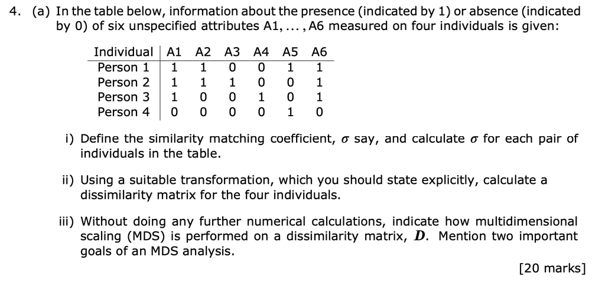

**Solution**

For each pair of individuals, $i$ and $j$ say, form a $2 \times 2$ table
$$\begin{array}{cccc}
&1 &0\\
1& a & b\\
0& c & d
\end{array}$$
where $a$ counts the number of attributes common to both individuals; $b$ counts the number of attributes present in individual $i$ but not $j$; $c$ counts the number of attributes $j$ has that $i$ does not; and
$d$ counts the number of attributes which neither $i$ of $j$ have.

The simple/similarity matching coefficient for individuals $i$ and $j$ is then given by
$$\sigma = \frac{a+d}{a+b+c+d}$$
It measures the level of agreement between the two individuals.

If we calculate this for each pair of individuals we get

- Person 1 and 2
  $$\begin{array}{cccc}
  &1 &0\\
  1& 3 & 1\\
  0& 1 & 1
  \end{array} \qquad \sigma=\frac{2}{3}$$
- Person 1 and 3
  $$\begin{array}{cccc}
  &1 &0\\
  1& 2 & 2\\
  0& 1 & 1
  \end{array} \qquad \sigma=\frac{1}{2}$$
- Person 1 and 4
  $$\begin{array}{cccc}
  &1 &0\\
  1& 1 & 3\\
  0& 0 & 2
  \end{array} \qquad \sigma=\frac{1}{2}$$
- Person 2 and 3
  $$\begin{array}{cccc}
  &1 &0\\
  1& 2 &2\\
  0& 1 & 1
  \end{array} \qquad \sigma=\frac{1}{2}$$
- Person 2 and 4
  $$\begin{array}{cccc}
  &1 &0\\
  1& 0 &4\\
  0& 1 & 1
  \end{array} \qquad \sigma=\frac{1}{6}$$
- Person 3 and 4
  $$\begin{array}{cccc}
  &1 &0\\
  1& 0 &3\\
  0& 1 & 2
  \end{array} \qquad \sigma=\frac{1}{3}$$
2. If $\mathbf S$ is a similarity matrix, then we can convert it to dissimilarity matrix $\mathbf D$ using the transformation
   $$d_{ij}=(s_{ii}+s_{jj}-2s_{ij})^{1/2}$$

Here it is appropriate to take $s_{ii}=1$. This gives the dissimilarity matrix

```r
S<- matrix(c(1, 2/3, 1/2, 1/2,
             2/3, 1, 1/2, 1/6,
             1/2, 1/2, 1, 1/3,
             1/2, 1/6, 1/3, 1), nr=4, byrow=T)
FtoD <- function(FF){
  n = dim(FF)[1]
  D <- matrix(nr=n,nc=n)
  for(ii in 1:n){
    for(jj in 1:n){
      D[ii,jj] <- sqrt(FF[ii,ii]+FF[jj,jj]-2*FF[ii,jj])
    }
  }
  return(D)
}

FtoD(S)
```

```
          [,1]      [,2]     [,3]     [,4]
[1,] 0.0000000 0.8164966 1.000000 1.000000
[2,] 0.8164966 0.0000000 1.000000 1.290994
[3,] 1.0000000 1.0000000 0.000000 1.154701
[4,] 1.0000000 1.2909944 1.154701 0.000000
```

3. Given a distance matrix $\mathbf D$, we define matrix $\mathbf A$ with entries $a_{ij} = -1/2 d_{ij}^2$, then calculate $\mathbf B= \mathbf H\mathbf A\mathbf H$ where $\mathbf H$ is the centering matrix.

If $\mathbf B$ is positive semi-definite, then $\mathbf D$ is a Euclidean distance matrix, but not if negative eigenvalues are present. In the latter case, we can use the positive definite part of $\mathbf B$

$$\mathbf B^+ = \sum_{i; \lambda_i \geq 0}\lambda_i \mathbf q_i \mathbf q_i^\top$$

One useful feature of MDS is that we can construct points in Euclidean space that have inter-point distances that are either approximately or exactly equal to the $d_{ij}$s. Two attractive features of MDS are i) dimension reduction and 2) visualizing datasets defined through a distance metric.